# partial RDA

Pablo E. Gutiérrez-Fonseca

01 December, 2021

#### **Step 1**

Load libraries.  
*Cargar las librerias que necesitas.*

```r
library(ggplot2)
library(dplyr)
library(vegan)
```

#### **Step 2**

Data  
*Cargar los datos.*

```r
species=read.csv("D:/Curriculum/07_ Cursos/Course_Multivariate_Stat_for_Ecological_Data/data/RDA_species.csv", header=T, row.names=NULL, sep=",")
env=read.csv("D:/Curriculum/07_ Cursos/Course_Multivariate_Stat_for_Ecological_Data/data/RDA_environmetal_standart.csv", header=T, row.names=NULL, sep=",")
```

#### **Step 3**

*Remover la columna de sitos.*

```r
species_1 <- select(species, -site)
env_1 <- select(env, -site)
```

#### **Step 4**

*Transformar datos.* *Hellinger es una transformacián recomendada por Legendre & Callagher (2001) en datos de abundancia y con una respuesta lineal.*

```r
species.hel <- decostand(species_1, method = "hellinger")
```

## **Partial RDA**

Basic formula: rda(Y ~ X + Condition(Z))  
*La formula básica es: rda(Y ~ X + Condition(Z))*

Partial RDA is a special case of RDA in which the response variables Y are related to explanatory variables X in the presence of additional explanatory variables, W, called covariables.  
*Un RDA parcial es un caso especial de un RDA simple en el que las **variables de respuesta Y** están relacionadas con las **variables explicativas X** en presencia de **variables explicativas adicionales, W,** llamadas **covariables**.*

Partial RDA is thus a powerful tool when users what to assess the effect of environmental variables on species composition while taking into account the species variation due to other environmental variables with no interest. *Por lo tanto, un RDA parcial es una herramienta poderosa cuando los usuarios evalúan el efecto de las variables ambientales en la composición de las especies, teniendo en cuenta la variación de las especies debido a otras variables ambientales sin “interés”.*

More information: Borcard et al (2012). page 172

#### **Step 1: partial RDA**

*Construir los modelos y ejecutar un RDA simple y un RDA parcial (i.e., controlado por covariables).*

```r
simple_rda <- rda(species.hel ~ temperature + oxygen + pH + conductivity +
                 plants + land_use + margin + season, data = env_1)

partial_rda <- rda(species.hel ~ temperature + oxygen + pH + conductivity +
                 plants + land_use + margin +
                Condition(season), data = env_1)

# anova(partial_rda, permutations = how(nperm = 999))
```

#### **Step 2: partial RDA**

Plot the results

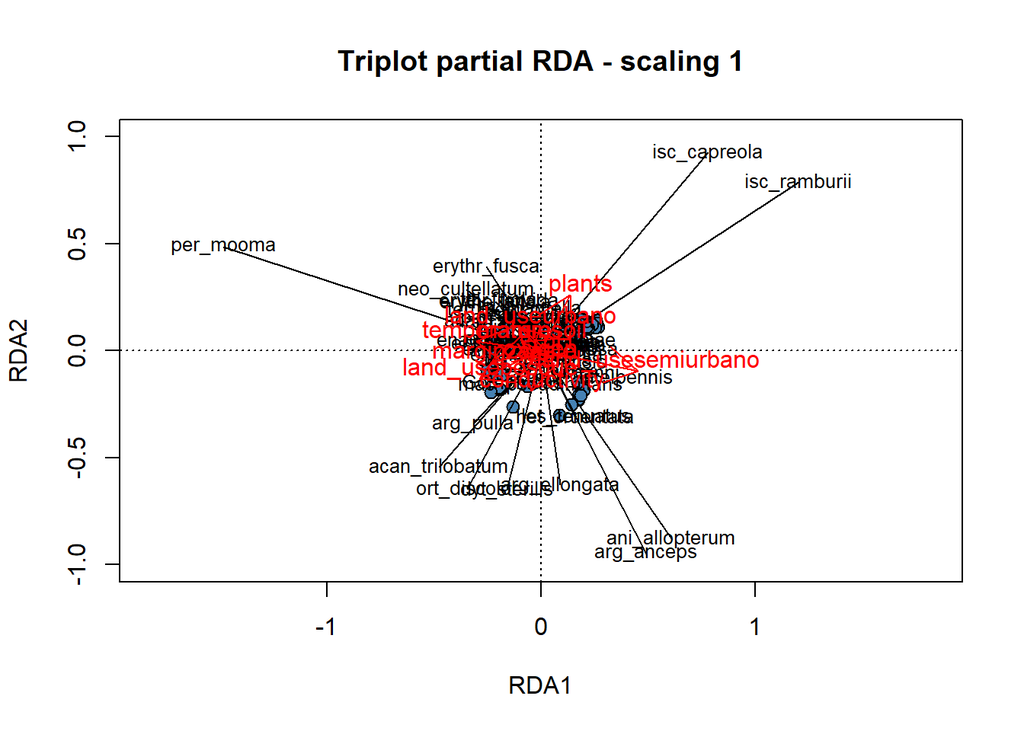

```r
#Construct the triplots
#Scaling 1

plot(partial_rda, scaling=1, main="Triplot partial RDA - scaling 1", type="none", xlab=c("RDA1"), ylab=c("RDA2"), xlim=c(-1,1), ylim=c(-1,1))
points(scores(partial_rda, display="sites", choices=c(1,2), scaling=1),
       pch=21, col="black", bg="steelblue", cex=1.2)
arrows(0,0,
       scores(partial_rda, display="species", choices=c(1), scaling=1),
       scores(partial_rda, display="species", choices=c(2), scaling=1),
       col="black",length=0)
text(scores(partial_rda, display="species", choices=c(1), scaling=1),
     scores(partial_rda, display="species", choices=c(2), scaling=1),
     labels=rownames(scores(partial_rda, display="species", scaling=1)),
     col="black", cex=0.8)
arrows(0,0,
      scores(partial_rda, display="bp", choices=c(1), scaling=1),
      scores(partial_rda, display="bp", choices=c(2), scaling=1),
      col="red")
text(scores(partial_rda, display="bp", choices=c(1), scaling=1)+0.05,
     scores(partial_rda, display="bp", choices=c(2), scaling=1)+0.05,
     labels=rownames(scores(partial_rda, display="bp", choices=c(2), scaling=1)),
     col="red", cex=1)
```

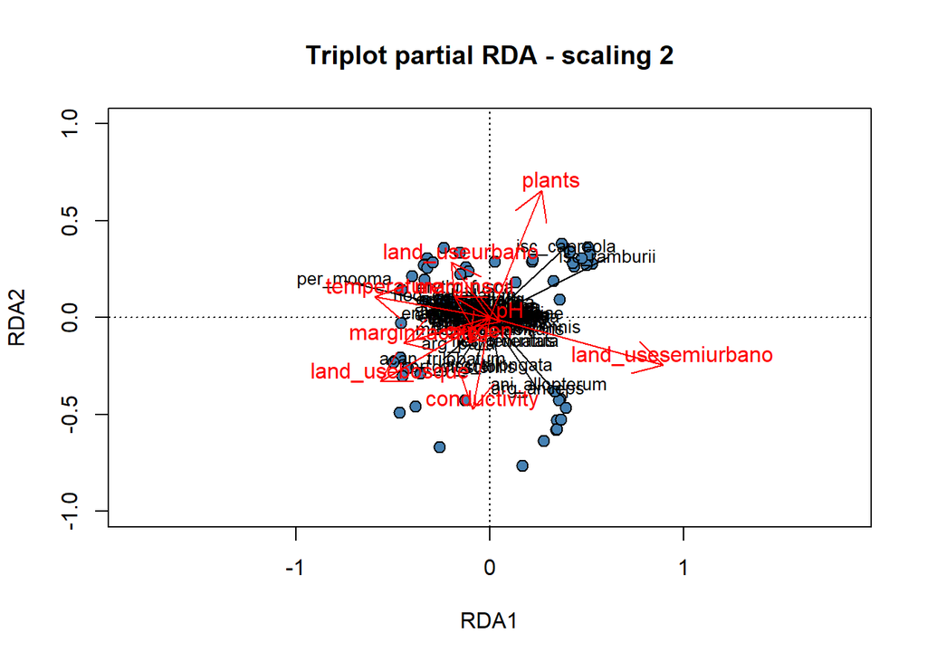

```r
#Scaling 2
plot(partial_rda, scaling=2, main="Triplot partial RDA - scaling 2", type="none", xlab=c("RDA1"), ylab=c("RDA2"), xlim=c(-1,1), ylim=c(-1,1))
points(scores(partial_rda, display="sites", choices=c(1,2), scaling=2),
       pch=21, col="black", bg="steelblue", cex=1.2)
arrows(0,0,
       scores(partial_rda, display="species", choices=c(1), scaling=2),
       scores(partial_rda, display="species", choices=c(2), scaling=2),
       col="black",length=0)
text(scores(partial_rda, display="species", choices=c(1), scaling=2),
     scores(partial_rda, display="species", choices=c(2), scaling=2),
     labels=rownames(scores(partial_rda, display="species", scaling=2)),
     col="black", cex=0.8)
arrows(0,0,
       scores(partial_rda, display="bp", choices=c(1), scaling=2),
       scores(partial_rda, display="bp", choices=c(2), scaling=2),
       col="red")
text(scores(partial_rda, display="bp", choices=c(1), scaling=2)+0.05,
     scores(partial_rda, display="bp", choices=c(2), scaling=2)+0.05,
     labels=rownames(scores(partial_rda, display="bp", choices=c(2), scaling=2)),
     col="red", cex=1)
```

#### **References**

https://wiki.qcbs.ca/r_workshop10

Legendre, P., & Legendre, L. (2012). Numerical ecology. Elsevier.